# SiqueiraCampos_wk7

Marco Siqueira Campos

15 de outubro de 2016

DATA 607  
MSDA CUNY

PROJECT 2  
ASSIGNMENT WK7 Working with XML and JSON in R

All files are in the Github github [link](https://github.com/MarcoSCampos/DATA607_wk7)

load library

```r
library(XML)
library(rjson)
library(RCurl)
```

The first was develop the code files with same information about books.

All was made by hand with Notepad++ editor, I try to follow the same struture for the data, as the strutures are different (table vs. tree) is not possible to do with absolute fidelity.

First html code and output display from firefox browser.

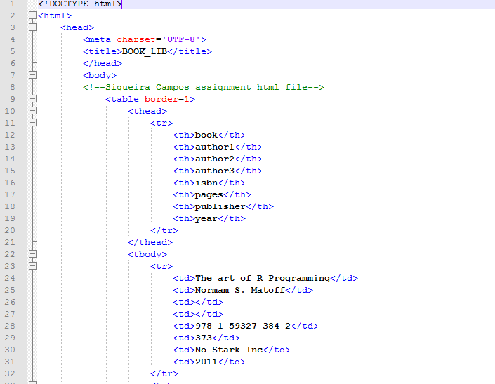

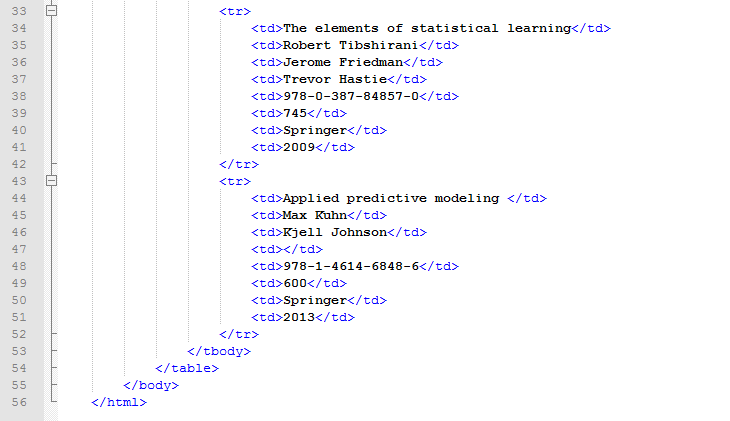

Html browser output

[figure not shown]

Next XML code was generated.

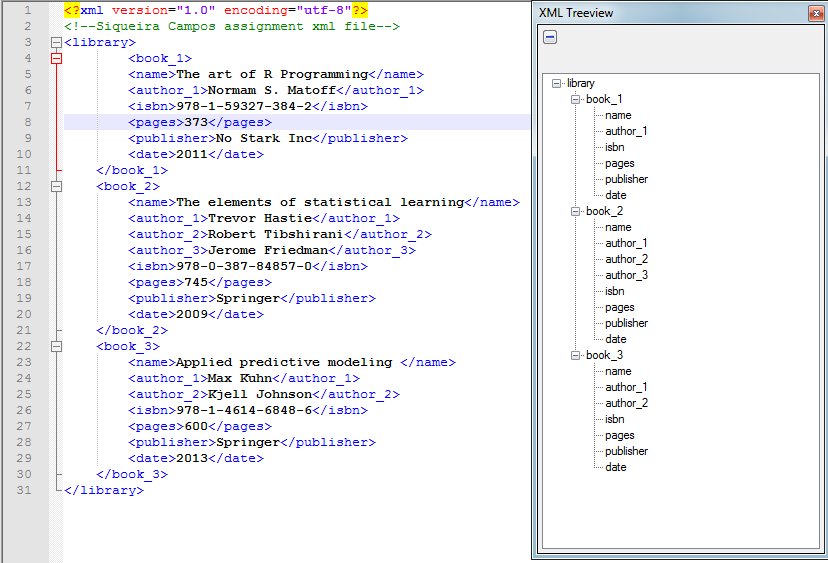

Next JSON code was generated.

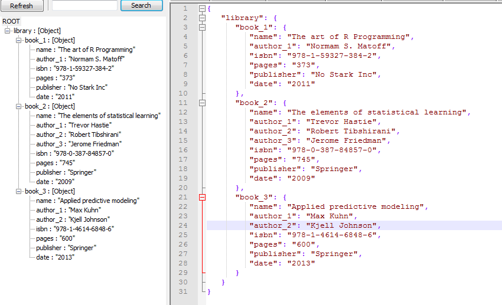

Read html file from github

```r
url<-getURL("https://raw.githubusercontent.com/MarcoSCampos/DATA607_wk7/master/books.html")
c<-readHTMLTable(url,header=TRUE, as.data.frame=TRUE,TRIM=TRUE,stringsAsFactors = FALSE)
```

remove column NULL and extract data frame from a list

```r
new_c<-as.data.frame(c$'NULL')
```

Check the data frame

```r
str(new_c)
```

```
## 'data.frame':    3 obs. of  8 variables:
##  $ book     : chr  "The art of R Programming" "The elements of statistical learning" "Applied predictive modeling"
##  $ author1  : chr  "Normam S. Matoff" "Robert Tibshirani" "Max Kuhn"
##  $ author2  : chr  "" "Jerome Friedman" "Kjell Johnson"
##  $ author3  : chr  "" "Trevor Hastie" ""
##  $ isbn     : chr  "978-1-59327-384-2" "978-0-387-84857-0" "978-1-4614-6848-6"
##  $ pages    : chr  "373" "745" "600"
##  $ publisher: chr  "No Stark Inc" "Springer" "Springer"
##  $ year     : chr  "2011" "2009" "2013"
```

Check one book

```r
new_c[1,]
```

```
##                       book          author1 author2 author3
## 1 The art of R Programming Normam S. Matoff
##                isbn pages    publisher year
## 1 978-1-59327-384-2   373 No Stark Inc 2011
```

The html data frame

```r
new_c
```

```
##                                   book           author1         author2
## 1             The art of R Programming  Normam S. Matoff
## 2 The elements of statistical learning Robert Tibshirani Jerome Friedman
## 3          Applied predictive modeling          Max Kuhn   Kjell Johnson
##         author3              isbn pages    publisher year
## 1               978-1-59327-384-2   373 No Stark Inc 2011
## 2 Trevor Hastie 978-0-387-84857-0   745     Springer 2009
## 3               978-1-4614-6848-6   600     Springer 2013
```

Read xml file from github

```r
url1<-getURL("https://raw.githubusercontent.com/MarcoSCampos/DATA607_wk7/master/books.xml")
parsed_xml<-xmlParse(url1)
```

Check raw xml file

```r
parsed_xml
```

```
## <?xml version="1.0" encoding="utf-8"?>
## <!--Siqueira Campos assignment xml file-->
## <library>
##   <book_1>
##     <name>The art of R Programming</name>
##     <author_1>Normam S. Matoff</author_1>
##     <isbn>978-1-59327-384-2</isbn>
##     <pages>373</pages>
##     <publisher>No Stark Inc</publisher>
##     <date>2011</date>
##   </book_1>
##   <book_2>
##     <name>The elements of statistical learning</name>
##     <author_1>Trevor Hastie</author_1>
##     <author_2>Robert Tibshirani</author_2>
##     <author_3>Jerome Friedman</author_3>
##     <isbn>978-0-387-84857-0</isbn>
##     <pages>745</pages>
##     <publisher>Springer</publisher>
##     <date>2009</date>
##   </book_2>
##   <book_3>
##     <name>Applied predictive modeling </name>
##     <author_1>Max Kuhn</author_1>
##     <author_2>Kjell Johnson</author_2>
##     <isbn>978-1-4614-6848-6</isbn>
##     <pages>600</pages>
##     <publisher>Springer</publisher>
##     <date>2013</date>
##   </book_3>
## </library>
##
```

Convert xml to data frame

```r
books_df<-xmlToDataFrame(parsed_xml)
```

View xml data frame

```r
books_df
```

```
##                                   name         author_1              isbn
## 1             The art of R Programming Normam S. Matoff 978-1-59327-384-2
## 2 The elements of statistical learning    Trevor Hastie 978-0-387-84857-0
## 3         Applied predictive modeling          Max Kuhn 978-1-4614-6848-6
##   pages    publisher date          author_2        author_3
## 1   373 No Stark Inc 2011              <NA>            <NA>
## 2   745     Springer 2009 Robert Tibshirani Jerome Friedman
## 3   600     Springer 2013     Kjell Johnson            <NA>
```

Read json file from github

```r
url2<-getURL("https://raw.githubusercontent.com/MarcoSCampos/DATA607_wk7/master/books.json")
```

Convert json file

```r
books_json<-fromJSON(url2)
```

Convert to a data frame

```r
books_json.df<-as.data.frame(books_json, stringsAsFactors = FALSE)
```

check the file

```r
str(books_json.df)
```

```
## 'data.frame':    1 obs. of  21 variables:
##  $ library.book_1.name     : chr "The art of R Programming"
##  $ library.book_1.author_1 : chr "Normam S. Matoff"
##  $ library.book_1.isbn     : chr "978-1-59327-384-2"
##  $ library.book_1.pages    : chr "373"
##  $ library.book_1.publisher: chr "No Stark Inc"
##  $ library.book_1.date     : chr "2011"
##  $ library.book_2.name     : chr "The elements of statistical learning"
##  $ library.book_2.author_1 : chr "Trevor Hastie"
##  $ library.book_2.author_2 : chr "Robert Tibshirani"
##  $ library.book_2.author_3 : chr "Jerome Friedman"
##  $ library.book_2.isbn     : chr "978-0-387-84857-0"
##  $ library.book_2.pages    : chr "745"
##  $ library.book_2.publisher: chr "Springer"
##  $ library.book_2.date     : chr "2009"
##  $ library.book_3.name     : chr "Applied predictive modeling"
##  $ library.book_3.author_1 : chr "Max Kuhn"
##  $ library.book_3.author_2 : chr "Kjell Johnson"
##  $ library.book_3.isbn     : chr "978-1-4614-6848-6"
##  $ library.book_3.pages    : chr "600"
##  $ library.book_3.publisher: chr "Springer"
##  $ library.book_3.date     : chr "2013"
```

See the data frame

```r
books_json.df
```

```
##        library.book_1.name library.book_1.author_1 library.book_1.isbn
## 1 The art of R Programming        Normam S. Matoff   978-1-59327-384-2
##   library.book_1.pages library.book_1.publisher library.book_1.date
## 1                  373             No Stark Inc                2011
##                    library.book_2.name library.book_2.author_1
## 1 The elements of statistical learning           Trevor Hastie
##   library.book_2.author_2 library.book_2.author_3 library.book_2.isbn
## 1       Robert Tibshirani         Jerome Friedman   978-0-387-84857-0
##   library.book_2.pages library.book_2.publisher library.book_2.date
## 1                  745                 Springer                2009
##           library.book_3.name library.book_3.author_1
## 1 Applied predictive modeling                Max Kuhn
##   library.book_3.author_2 library.book_3.isbn library.book_3.pages
## 1           Kjell Johnson   978-1-4614-6848-6                  600
##   library.book_3.publisher library.book_3.date
## 1                 Springer                2013
```

## Conclusion:

Are the three data frames identical? No.